# Kaggle - Super Heroes Data

Sneha Kannan

Dataset: https://www.kaggle.com/claudiodavi/superhero-set/data

This is a dataset from Kaggle about Superheroes. It consists of two parts, one containing demographic type of information and another with a list of super powers of the superheroes.

```r
library(tidyverse)
library(janitor)
library(scales)
library(knitr)
library(kableExtra)
library(patchwork)
library(skimr)

theme_set(theme_bw())

# clean_names() funtion will make sure that the column names in the dataset will have underscore , alphabets and numbers. All column names will be converted to lower case by default
heroes_information_df <- read.csv('data/heroes_information.csv') %>%
                          janitor::clean_names()
super_hero_powers_df <- read.csv('data/super_hero_powers.csv') %>%
                          janitor::clean_names()
```

#### **Data Cleaning**

There are 19 rows with duplicate value of *names* of superheroes. This needs to be investigated.

```r
heroes_information_df %>%
  summarise(num_distinct_superheroes = n_distinct(name),
            num_superheroes = n())
```

```
##   num_distinct_superheroes num_superheroes
## 1                      715             734
```

tabyl() function is useful to find out the count of factor levels in a column. Here is a look at those superheroes which occur more than once.

```r
dup_names <- heroes_information_df %>%
  janitor::tabyl(name) %>%
  filter(n>1)

#Contains names of superheroes which are repeated
dup_names
```

```
##              name n     percent
## 1           Angel 2 0.002724796
## 2           Atlas 2 0.002724796
## 3            Atom 2 0.002724796
## 4         Batgirl 2 0.002724796
## 5          Batman 2 0.002724796
## 6    Black Canary 2 0.002724796
## 7        Blizzard 2 0.002724796
## 8     Blue Beetle 2 0.002724796
## 9  Captain Marvel 2 0.002724796
## 10      Firestorm 2 0.002724796
## 11        Goliath 3 0.004087193
## 12          Namor 2 0.002724796
## 13           Nova 2 0.002724796
## 14         Speedy 2 0.002724796
## 15     Spider-Man 3 0.004087193
## 16          Toxin 2 0.002724796
## 17     Vindicator 2 0.002724796
```

```r
#Another way to do the same thing

# dup_names <- heroes_information_df %>%
#   group_by(name) %>%
#   summarise(n = n()) %>%
#   filter(n > 1)
```

Here’s the dataframe containing the duplicate superheroes

```r
heroes_information_df %>%
  filter(name %in% dup_names$name) %>%
  kable() %>%
  kable_styling(full_width = FALSE)
```

x

name

gender

eye_color

race

hair_color

height

publisher

skin_color

alignment

weight

22

Angel

Male

blue

Blond

183

Marvel Comics

good

68

23

Angel

Male

Vampire

-99

Dark Horse Comics

good

-99

47

Atlas

Male

brown

Mutant

Red

183

Marvel Comics

good

101

48

Atlas

Male

blue

God / Eternal

Brown

198

DC Comics

bad

126

49

Atom

Male

blue

Red

178

DC Comics

good

68

50

Atom

Male

-99

DC Comics

good

-99

62

Batgirl

Female

-99

DC Comics

good

-99

63

Batgirl

Female

green

Human

Red

170

DC Comics

good

57

68

Batman

Male

blue

Human

black

188

DC Comics

good

95

69

Batman

Male

blue

Human

Black

178

DC Comics

good

77

96

Black Canary

Female

blue

Human

Blond

165

DC Comics

good

58

97

Black Canary

Female

blue

Metahuman

Blond

170

DC Comics

good

59

115

Blizzard

Male

-99

Marvel Comics

bad

-99

116

Blizzard

Male

Brown

-99

Marvel Comics

bad

-99

122

Blue Beetle

Male

blue

Brown

-99

DC Comics

good

-99

123

Blue Beetle

Male

-99

DC Comics

good

-99

155

Captain Marvel

Female

blue

Human-Kree

Blond

180

Marvel Comics

good

74

156

Captain Marvel

Male

blue

Human

Black

193

DC Comics

good

101

259

Firestorm

Male

brown

Black

-99

DC Comics

good

-99

260

Firestorm

Male

blue

Human

Auburn

188

DC Comics

good

91

289

Goliath

Male

-99

Marvel Comics

good

-99

290

Goliath

Male

Human

-99

Marvel Comics

good

-99

291

Goliath

Male

Human

-99

Marvel Comics

good

-99

481

Namor

Male

-99

Marvel Comics

good

-99

482

Namor

Male

grey

Atlantean

Black

188

Marvel Comics

good

125

496

Nova

Male

brown

Human

Brown

185

Marvel Comics

good

86

497

Nova

Female

white

Human / Cosmic

Red

163

Marvel Comics

gold

good

59

617

Speedy

Male

Human

-99

DC Comics

good

-99

618

Speedy

Female

green

Human

Brown

-99

DC Comics

good

-99

622

Spider-Man

Male

hazel

Human

Brown

178

Marvel Comics

good

74

623

Spider-Man

red

Human

Brown

178

Marvel Comics

good

77

624

Spider-Man

Male

brown

Human

Black

157

Marvel Comics

good

56

673

Toxin

Male

blue

Symbiote

Brown

188

Marvel Comics

good

97

674

Toxin

Male

black

Symbiote

Blond

191

Marvel Comics

good

117

695

Vindicator

Female

green

Human

Red

165

Marvel Comics

good

54

696

Vindicator

Male

-99

Marvel Comics

good

-99

From this table, there are primarily two different reasons for the duplicates:

**1.** Between two rows, some columns are missing for the same superhero (maybe double entry where one of it is incomplete). Example: x = 49 and 50, 62 and 63. For such groups it’s better to remove the one with incomplete data

**2.** Incorrect data in one row compared to the other

Removing duplicates because of (1) was easy. To remove duplicates caused by (2) a lot of manual work was involved. On Googling about the superheroes, I removed those which had incorrect information.

```r
#Manual cleaning by removing rows
dup_rows <- c(23, 48, 50, 62, 69, 96, 115, 123, 155, 259, 289, 290, 481, 496, 617, 623, 624, 674, 696)

#Deduped dataframe with the superheroes information
heroes_information_deduped_df <- heroes_information_df %>%
  filter(!(x %in% dup_rows))

#Taking a look at the dataframe again
heroes_information_deduped_df %>%
  filter(name %in% dup_names$name) %>%
  kable() %>%
  kable_styling(full_width = FALSE)
```

x

name

gender

eye_color

race

hair_color

height

publisher

skin_color

alignment

weight

22

Angel

Male

blue

Blond

183

Marvel Comics

good

68

47

Atlas

Male

brown

Mutant

Red

183

Marvel Comics

good

101

49

Atom

Male

blue

Red

178

DC Comics

good

68

63

Batgirl

Female

green

Human

Red

170

DC Comics

good

57

68

Batman

Male

blue

Human

black

188

DC Comics

good

95

97

Black Canary

Female

blue

Metahuman

Blond

170

DC Comics

good

59

116

Blizzard

Male

Brown

-99

Marvel Comics

bad

-99

122

Blue Beetle

Male

blue

Brown

-99

DC Comics

good

-99

156

Captain Marvel

Male

blue

Human

Black

193

DC Comics

good

101

260

Firestorm

Male

blue

Human

Auburn

188

DC Comics

good

91

291

Goliath

Male

Human

-99

Marvel Comics

good

-99

482

Namor

Male

grey

Atlantean

Black

188

Marvel Comics

good

125

497

Nova

Female

white

Human / Cosmic

Red

163

Marvel Comics

gold

good

59

618

Speedy

Female

green

Human

Brown

-99

DC Comics

good

-99

622

Spider-Man

Male

hazel

Human

Brown

178

Marvel Comics

good

74

673

Toxin

Male

blue

Symbiote

Brown

188

Marvel Comics

good

97

695

Vindicator

Female

green

Human

Red

165

Marvel Comics

good

54

#### **How many different Publishers are there?**

```r
heroes_information_deduped_df %>%
    summarise(num_distinct_publishers = n_distinct(publisher))
```

```
##   num_distinct_publishers
## 1                      25
```

There are 25 distinct publishers.

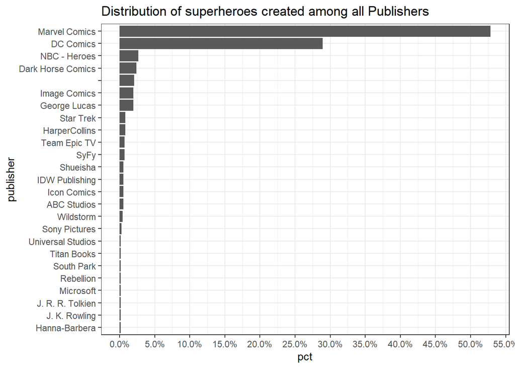

```r
heroes_information_deduped_df %>%
  group_by(publisher) %>%
  summarise(n = n()) %>%
  mutate(total = sum(n),
         pct = n/total,
         publisher = fct_reorder(publisher, pct)) %>%
  ggplot(aes(x=publisher, y = pct)) +
  geom_col() +
  scale_y_continuous(labels = percent, breaks = seq(0, .60, .05)) +
  coord_flip() +
  ggtitle('Distribution of superheroes created among all Publishers')
```

**DC Comics** and **Marvel Comics** are the biggest publishers creating about 29% and 53% of the superheroes respectively

Using fct_lump() function to lump together all publishers other than Marvel and DC into ‘Other’ since the rest of the publishers form a small part out of the entire population.

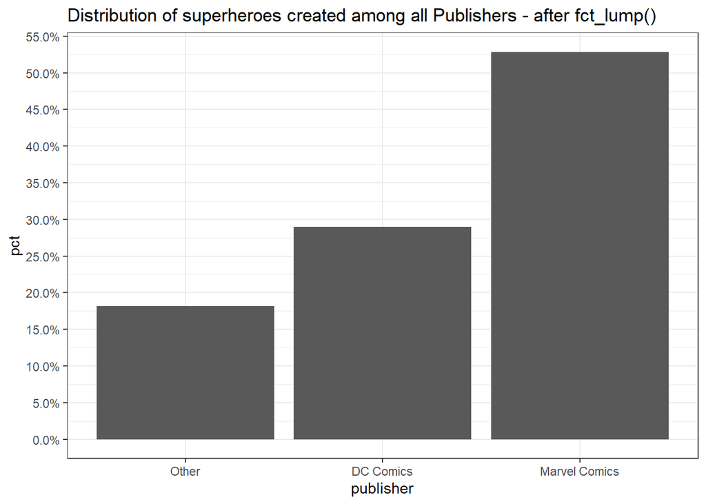

```r
heroes_information_deduped_df %>%
  mutate(publisher = fct_lump(publisher, n = 2)) %>%
  group_by(publisher) %>%
  summarise(n = n()) %>%
  mutate(total = sum(n),
         pct = n/total,
         publisher = fct_reorder(publisher, pct)) %>%
  ggplot(aes(x=publisher, y = pct)) +
  geom_col() +
  scale_y_continuous(labels = percent, breaks = seq(0, .60, .05)) +
  ggtitle('Distribution of superheroes created among all Publishers - after fct_lump()')
```

#### **Do the publishers create more good or bad heroes?**

DC and Marvel have a similar distribution among good and bad superheroes. Approximately 65% of their superheroes are good and about 30% of them are bad. The rest of the publishers (‘Other’) seem to produce a slightly higher percentage of good heroes, about 72%.

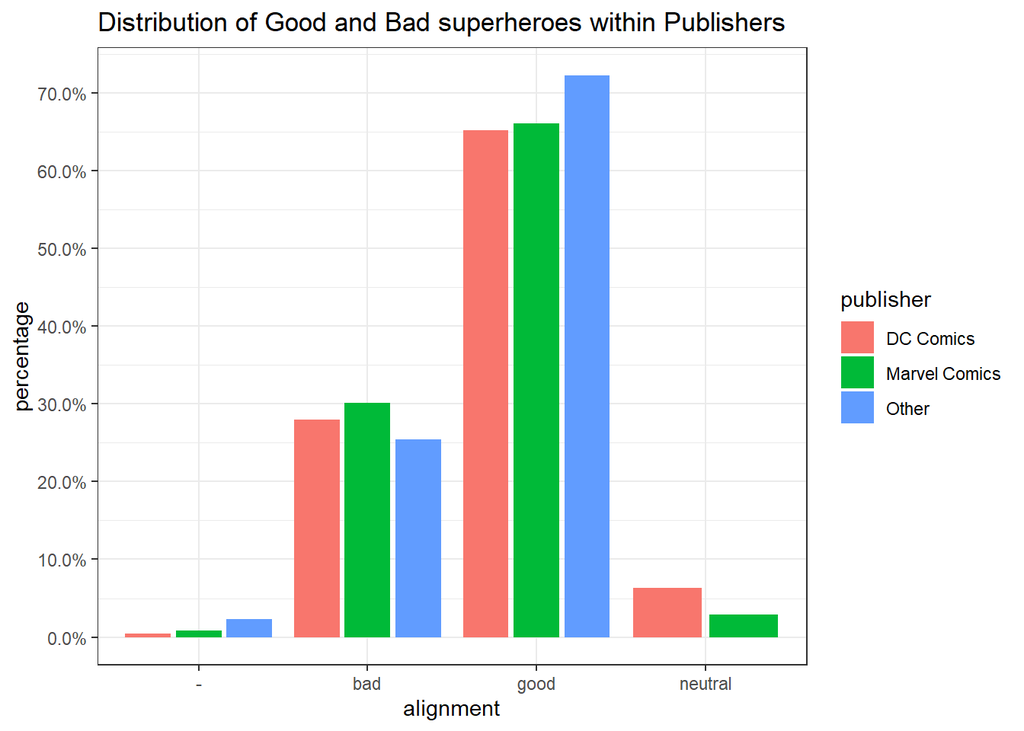

```r
heroes_information_deduped_df %>%
  mutate(publisher = fct_lump(publisher, n = 2)) %>%
  group_by(publisher, alignment) %>%
  summarize(n = n()) %>%
  mutate(percentage = n / sum(n)) %>%
  ggplot(aes(x=alignment, y = percentage, fill = publisher))+
  geom_col(position = "dodge2") +
  scale_y_continuous(labels = percent, breaks = seq(0, .80, .10)) +
  ggtitle('Distribution of Good and Bad superheroes within Publishers')
```

#### **Percentage Distributions**

These plots show the frequency distribution among some features of Superheroes [Hair Color, Eye Color] by specific groups [Alignment, Producers, Gender]

I’ve used the [patchwork](https://patchwork.data-imaginist.com/index.html) package to show the plots. I wanted to order the percentages by the descending order but was unable to do it the way I wanted to when I used facet_wrap in ggplot(). This [link](https://stackoverflow.com/questions/52029785/sorting-in-ggplot-with-facet-wrap) from Stackoverflow has some workarounds but the end result was some unordered plots because not all features are present among all the groups. Thanks to patchwork for helping me create these plots.

##### **Hair Color - Alignment**

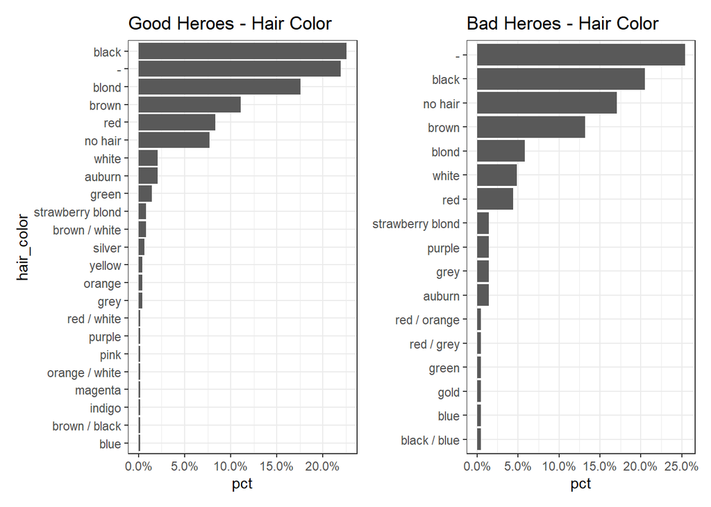

```r
hair_good <- heroes_information_deduped_df %>%
  filter(alignment %in% c('good')) %>%
  mutate(hair_color = tolower(hair_color),
         hair_color = ifelse(hair_color == 'brownn', 'brown', hair_color)) %>%
  group_by(hair_color) %>%
  summarise(n = n()) %>%
  mutate(total = sum(n),
         pct = n/total,
         hair_color = fct_reorder(hair_color, pct)) %>%
  ggplot(aes(hair_color, pct)) +
  geom_col() +
  scale_y_continuous(labels = percent)+
  coord_flip()+
  ggtitle('Good Heroes - Hair Color')

hair_bad <- heroes_information_deduped_df %>%
  filter(alignment %in% c('bad')) %>%
  mutate(hair_color = tolower(hair_color),
         hair_color = ifelse(hair_color == 'brownn', 'brown', hair_color)) %>%
  group_by(hair_color) %>%
  summarise(n = n()) %>%
  mutate(total = sum(n),
         pct = n/total,
         hair_color = fct_reorder(hair_color, pct)) %>%
  ggplot(aes(hair_color, pct)) +
  geom_col() +
  scale_y_continuous(labels = percent)+
  theme(axis.title.y=element_blank()) +
  coord_flip()+
  ggtitle('Bad Heroes - Hair Color')

#Using the patchwork package to join two plots together
hair_good + hair_bad
```

For the bad superheroes, data is missing for 25% of them. Black is the most common hair color followed by ‘No Hair’.

##### **Hair Color - Publisher**

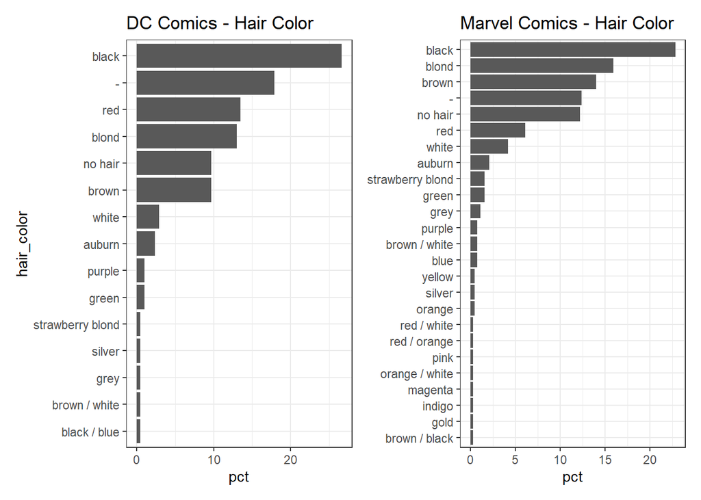

```r
hair_dc <- heroes_information_deduped_df %>%
  filter(publisher %in% c('DC Comics')) %>%
  mutate(hair_color = tolower(hair_color),
         hair_color = ifelse(hair_color == 'brownn', 'brown', hair_color)) %>%
  group_by(hair_color) %>%
  summarise(n = n()) %>%
  mutate(pct = round(n*100/sum(n),1),
         hair_color = fct_reorder(hair_color, pct)) %>%
  ggplot(aes(x=hair_color, y = pct)) +
  geom_col() +
  coord_flip()+
  ggtitle('DC Comics - Hair Color')

hair_marvel <- heroes_information_deduped_df %>%
  filter(publisher %in% c('Marvel Comics')) %>%
  mutate(hair_color = tolower(hair_color),
         hair_color = ifelse(hair_color == 'brownn', 'brown', hair_color)) %>%
  group_by(hair_color) %>%
  summarise(n = n()) %>%
  mutate(pct = round(n*100/sum(n),1),
         hair_color = fct_reorder(hair_color, pct)) %>%
  ggplot(aes(x=hair_color, y = pct)) +
  geom_col() +
  theme(axis.title.y=element_blank()) +
  coord_flip()+
  ggtitle('Marvel Comics - Hair Color')

hair_dc + hair_marvel
```

Super heroes from Marvel Comics have a more colors for their hair than those from DC Comics.

##### **Eye Color - Alignment**

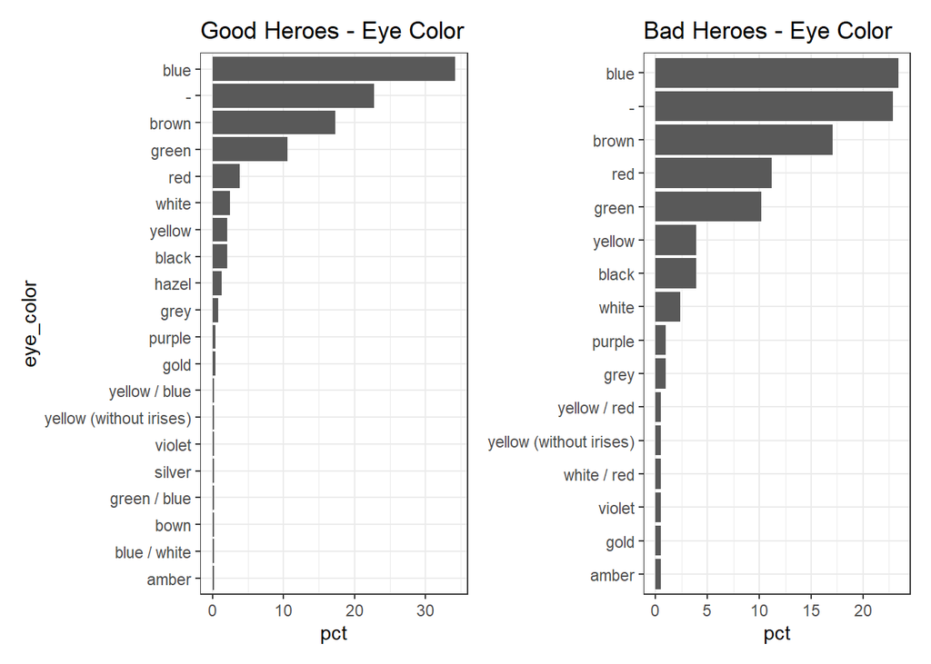

```r
eye_good <- heroes_information_deduped_df %>%
  filter(alignment %in% c('good')) %>%
  mutate(eye_color = tolower(eye_color)
         ) %>%
  group_by(eye_color) %>%
  summarise(n = n()) %>%
  mutate(pct = round(n*100/sum(n),1),
         eye_color = fct_reorder(eye_color, pct)) %>%
  ggplot(aes(x=eye_color, y = pct)) +
  geom_col() +
  coord_flip()+
  ggtitle('Good Heroes - Eye Color')

eye_bad <- heroes_information_deduped_df %>%
  filter(alignment %in% c('bad')) %>%
  mutate(eye_color = tolower(eye_color)
         ) %>%
  group_by(eye_color) %>%
  summarise(n = n()) %>%
  mutate(pct = round(n*100/sum(n),1),
         eye_color = fct_reorder(eye_color, pct)) %>%
  ggplot(aes(x=eye_color, y = pct)) +
  geom_col() +
  theme(axis.title.y=element_blank()) +
  coord_flip()+
  ggtitle('Bad Heroes - Eye Color')

eye_good + eye_bad
```

34% of the good superheroes have blue eyes while 23% of the bad superheroes have blue eyes. 12% of bad superheroes have red eyes but less than 5% of the good superheroes have red eyes. Brown is a common eye color among good and bad superheroes.

##### **Eye Color - Publisher**

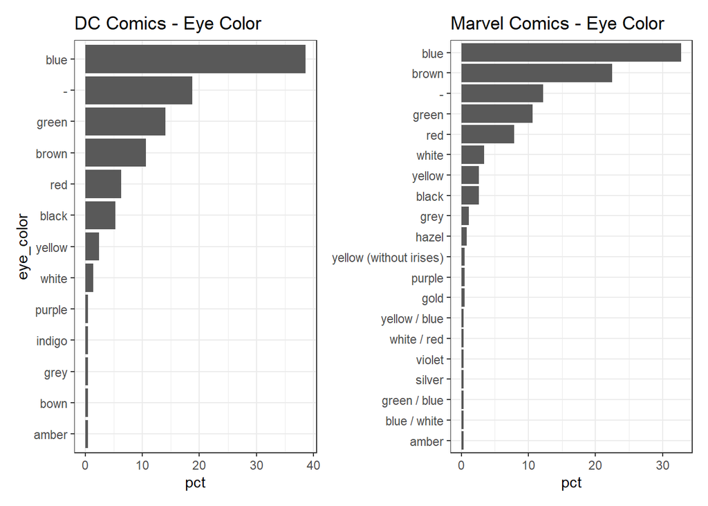

```r
eye_dc <- heroes_information_deduped_df %>%
  filter(publisher %in% c('DC Comics')) %>%
  mutate(eye_color = tolower(eye_color)
         ) %>%
  group_by(eye_color) %>%
  summarise(n = n()) %>%
  mutate(pct = round(n*100/sum(n),1),
         eye_color = fct_reorder(eye_color, pct)) %>%
  ggplot(aes(x=eye_color, y = pct)) +
  geom_col() +
  coord_flip()+
  ggtitle('DC Comics - Eye Color')

eye_marvel <- heroes_information_deduped_df %>%
  filter(publisher %in% c('Marvel Comics')) %>%
  mutate(eye_color = tolower(eye_color)
         ) %>%
  group_by(eye_color) %>%
  summarise(n = n()) %>%
  mutate(pct = round(n*100/sum(n),1),
         eye_color = fct_reorder(eye_color, pct)) %>%
  ggplot(aes(x=eye_color, y = pct)) +
  geom_col() +
  theme(axis.title.y=element_blank()) +
  coord_flip()+
  ggtitle('Marvel Comics - Eye Color')

eye_dc + eye_marvel
```

38% of DC Comics and 33% of Marvel Comics superheroes have blue eyes. Brown eyed superheroes are more common among Marvel Comics and Green eyed superheroes are more common among DC Comics.

##### **Eye Color - Gender**

68.5% of the superheroes are Men and 27.5% of them are Women. 4% don’t have a specified gender

```r
heroes_information_deduped_df %>%
  group_by(gender) %>%
  summarise(n = n()) %>%
  mutate(pct = round(n*100/sum(n), 1))
```

```
## # A tibble: 3 x 3
##   gender     n   pct
##   <fct>  <int> <dbl>
## 1 -         28   3.9
## 2 Female   197  27.6
## 3 Male     490  68.5
```

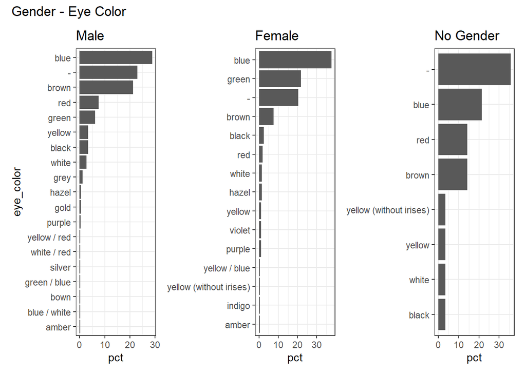

```r
eye_male <- heroes_information_deduped_df %>%
  filter(gender == 'Male') %>%
  mutate(eye_color = tolower(eye_color)
         ) %>%
  group_by(eye_color) %>%
  summarise(n = n()) %>%
  mutate(pct = round(n*100/sum(n),1),
         eye_color = fct_reorder(eye_color, pct)) %>%
  ggplot(aes(x=eye_color, y = pct)) +
  geom_col() +
  coord_flip()+
  ggtitle('Male')

eye_female <- heroes_information_deduped_df %>%
  filter(gender == 'Female') %>%
  mutate(eye_color = tolower(eye_color)
         ) %>%
  group_by(eye_color) %>%
  summarise(n = n()) %>%
  mutate(pct = round(n*100/sum(n),1),
         eye_color = fct_reorder(eye_color, pct)) %>%
  ggplot(aes(x=eye_color, y = pct)) +
  geom_col() +
  theme(axis.title.y=element_blank()) +
  coord_flip()+
  ggtitle('Female')

eye_null <- heroes_information_deduped_df %>%
  filter(gender == '-') %>%
  mutate(eye_color = tolower(eye_color)
         ) %>%
  group_by(eye_color) %>%
  summarise(n = n()) %>%
  mutate(pct = round(n*100/sum(n),1),
         eye_color = fct_reorder(eye_color, pct)) %>%
  ggplot(aes(x=eye_color, y = pct)) +
  geom_col() +
  theme(axis.title.y=element_blank()) +
  coord_flip()+
  ggtitle('No Gender')

p1 <- (eye_male + eye_female + eye_null)

p1 + plot_annotation(title = 'Gender - Eye Color')
```

#### **Height and Weight of superheroes**

##### **Height**

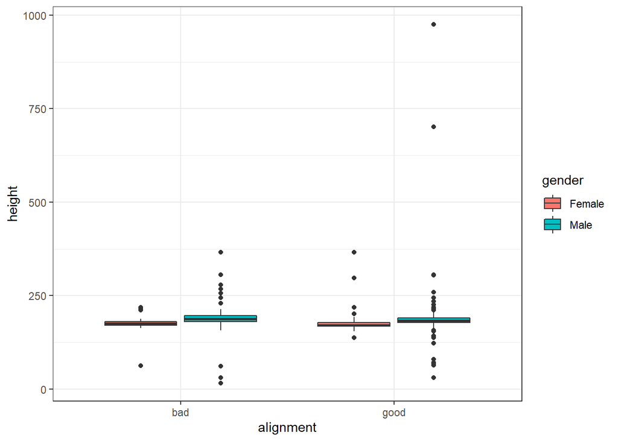

```r
heroes_information_deduped_df %>%
  filter(!gender %in% c('-'),
         alignment %in% c('good', 'bad')) %>%
  mutate(height = ifelse(height < 0, NA, height),
         weight = ifelse(weight < 0, NA, weight)) %>%
  ggplot(aes(x=alignment, y=height, fill=gender)) +
  geom_boxplot()
```

The function skim() from skimr package is useful to find out the Five Number summary for numeric values and also has the histograms for the frequency distribution.

Bad Men follow a normal distribution. Good Men and Women are skewed right while Bad Women are skewed left.

```r
heroes_information_deduped_df %>%
  filter(!gender %in% c('-'),
         alignment %in% c('good', 'bad')) %>%
  mutate(height = ifelse(height < 0, NA, height),
         weight = ifelse(weight < 0, NA, weight)) %>%
  group_by(gender, alignment) %>%
  skimr::skim(height) %>%
  select(-skim_type, -skim_variable, -n_missing, -numeric.sd) %>%
  kable() %>%
  kable_styling(full_width = FALSE)
```

| gender | alignment | complete_rate | numeric.mean | numeric.p0 | numeric.p25 | numeric.p50 | numeric.p75 | numeric.p100 | numeric.hist |
| --- | --- | --- | --- | --- | --- | --- | --- | --- | --- |
| Female | bad | 0.7142857 | 174.3800 | 62.5 | 170 | 175 | 180.00 | 218 | ▁▁▁▇▂ |
| Female | good | 0.7278481 | 174.8000 | 137.0 | 168 | 170 | 178.00 | 366 | ▇▁▁▁▁ |
| Male | bad | 0.7300613 | 190.1571 | 15.2 | 180 | 188 | 196.00 | 366 | ▁▁▇▁▁ |
| Male | good | 0.7062706 | 189.1696 | 30.5 | 178 | 183 | 190.25 | 975 | ▇▁▁▁▁ |

##### **Weight**

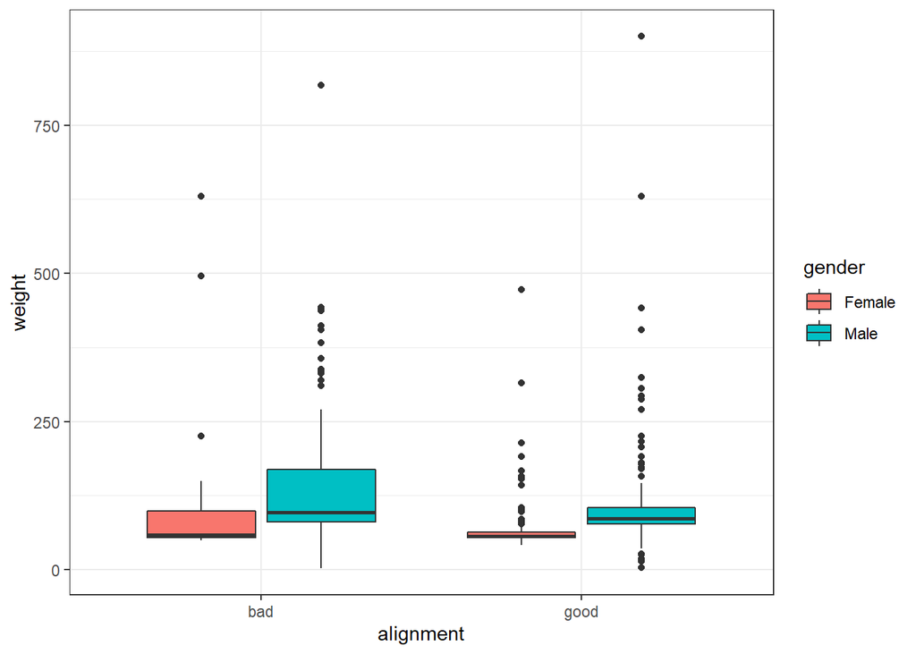

```r
heroes_information_deduped_df %>%
  filter(!gender %in% c('-'),
         alignment %in% c('good', 'bad')) %>%
  mutate(height = ifelse(height < 0, NA, height),
         weight = ifelse(weight < 0, NA, weight)) %>%
  ggplot(aes(x=alignment, y=weight, fill=gender)) +
  geom_boxplot()
```

There are 205 superheroes with missing weight. Among all the bad superheroes, men have a wider spread in weight than women.

```r
heroes_information_deduped_df %>%
  filter(!gender %in% c('-'),
         alignment %in% c('good', 'bad')) %>%
  mutate(height = ifelse(height < 0, NA, height),
         weight = ifelse(weight < 0, NA, weight)) %>%
  group_by(gender, alignment) %>%
  skimr::skim(weight) %>%
  select(-skim_type, -skim_variable, -n_missing, -numeric.sd) %>%
  kable() %>%
  kable_styling(full_width = FALSE)
```

| gender | alignment | complete_rate | numeric.mean | numeric.p0 | numeric.p25 | numeric.p50 | numeric.p75 | numeric.p100 | numeric.hist |
| --- | --- | --- | --- | --- | --- | --- | --- | --- | --- |
| Female | bad | 0.7428571 | 114.6154 | 50 | 54.25 | 59 | 98.75 | 630 | ▇▁▁▁▁ |
| Female | good | 0.7088608 | 71.1250 | 41 | 54.00 | 57 | 63.00 | 473 | ▇▁▁▁▁ |
| Male | bad | 0.6932515 | 144.1681 | 2 | 81.00 | 97 | 169.00 | 817 | ▇▂▁▁▁ |
| Male | good | 0.6699670 | 108.5616 | 4 | 77.00 | 86 | 105.00 | 900 | ▇▁▁▁▁ |

All the four groups are skewed right.

#### **Superhero Powers**

```r
super_hero_powers_df %>%
  select(1:7) %>%
  head() %>%
  kable() %>%
  kable_styling(full_width = FALSE)
```

| hero_names | agility | accelerated_healing | lantern_power_ring | dimensional_awareness | cold_resistance | durability |
| --- | --- | --- | --- | --- | --- | --- |
| 3-D Man | True | False | False | False | False | False |
| A-Bomb | False | True | False | False | False | True |
| Abe Sapien | True | True | False | False | True | True |
| Abin Sur | False | False | True | False | False | False |
| Abomination | False | True | False | False | False | False |
| Abraxas | False | False | False | True | False | False |

It has a list of all the superhero powers for the heroes. As seen from the sample data, the columns were read in as factors. The below code snippet maps the columns from True and False to 1 and 0.

```r
super_hero_powers_transformed_df <- super_hero_powers_df %>%
  mutate_if(is.factor, as.character) %>%
  mutate_if(!names(.) %in% c('hero_names'),
            list(~as.logical(.))) %>%
  mutate_if(is.logical,as.numeric)

super_hero_powers_transformed_df %>%
  select(1:7) %>%
  head() %>%
  kable() %>%
  kable_styling(full_width = FALSE)
```

| hero_names | agility | accelerated_healing | lantern_power_ring | dimensional_awareness | cold_resistance | durability |
| --- | --- | --- | --- | --- | --- | --- |
| 3-D Man | 1 | 0 | 0 | 0 | 0 | 0 |
| A-Bomb | 0 | 1 | 0 | 0 | 0 | 1 |
| Abe Sapien | 1 | 1 | 0 | 0 | 1 | 1 |
| Abin Sur | 0 | 0 | 1 | 0 | 0 | 0 |
| Abomination | 0 | 1 | 0 | 0 | 0 | 0 |
| Abraxas | 0 | 0 | 0 | 1 | 0 | 0 |

There are some rows which are present in one dataframe but not in the other. I have decided to do an inner_join between the two dataframes so only the common rows are selected.

```r
nrow(heroes_information_deduped_df)
```

```
## [1] 715
```

```r
nrow(super_hero_powers_transformed_df)
```

```
## [1] 667
```

```r
superhero_df <- heroes_information_deduped_df %>%
  inner_join(super_hero_powers_transformed_df, by = c("name" = "hero_names"))

nrow(superhero_df)
```

```
## [1] 643
```

#### **Superhero Powers**

For analyzing this dataset, I have selected only those superheoes who are present in both the datasets (hero_information and superhero_powers)

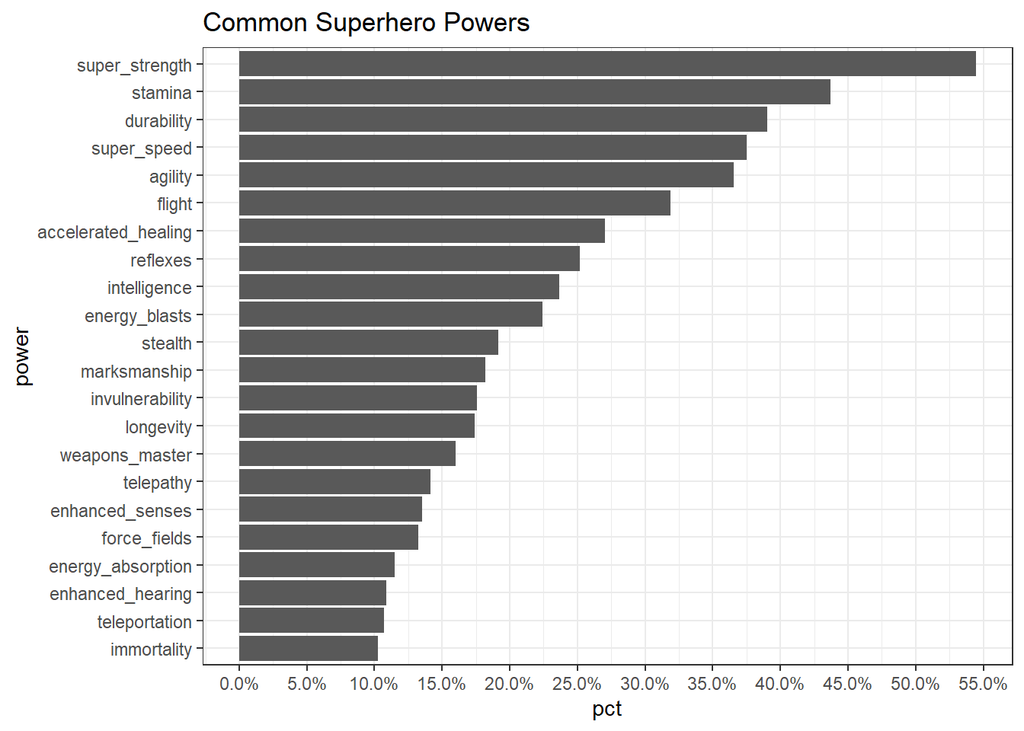

```r
 super_hero_powers_transformed_df %>%
  filter(hero_names %in% heroes_information_deduped_df$name) %>%
  summarise_if(is.numeric, sum, na.rm=TRUE) %>%
  pivot_longer(
    cols = colnames(.),
    names_to = "power",
    values_to = "count") %>%
    mutate(pct = count/643) %>%
    arrange(desc(count)) %>%
  filter(pct > 0.1) %>%
  mutate(power = fct_reorder(power, pct)) %>%
  ggplot(aes(x=power, y = pct))+
  geom_col() +
  scale_y_continuous(labels = percent, breaks = seq(0, .60, .05)) +
  coord_flip() +
  ggtitle('Common Superhero Powers')
```

As one should expect, the most common superhero power is *Super Strength*, 55% of the heroes have this power. *Stamina*, *Durability*, *Super Speed*, *Agility*, *Flight* are the top powers among the superheroes.

[figure not shown]

```r
 super_hero_powers_transformed_df %>%
  filter(hero_names %in% heroes_information_deduped_df$name) %>%
  mutate(num_powers = select(., agility:omniscient) %>% rowSums(na.rm=TRUE)) %>%
  select(hero_names, num_powers) %>%
  arrange(desc(num_powers)) %>%
  filter(num_powers > 25) %>%
  mutate(hero_names = fct_reorder(hero_names, num_powers)) %>%
  ggplot(aes(x=hero_names, y = num_powers)) +
  geom_col() +
  coord_flip()
```

*Spectre* created by DC Comics is the most powerful hero with almost 50 superpowers. *Amazo* comes a close second with about 44 superpowers. *Martian Manhunter*, *Living Tribunal* and *Man of Miracles* make it to the top 5 group in terms of number of superheroes.

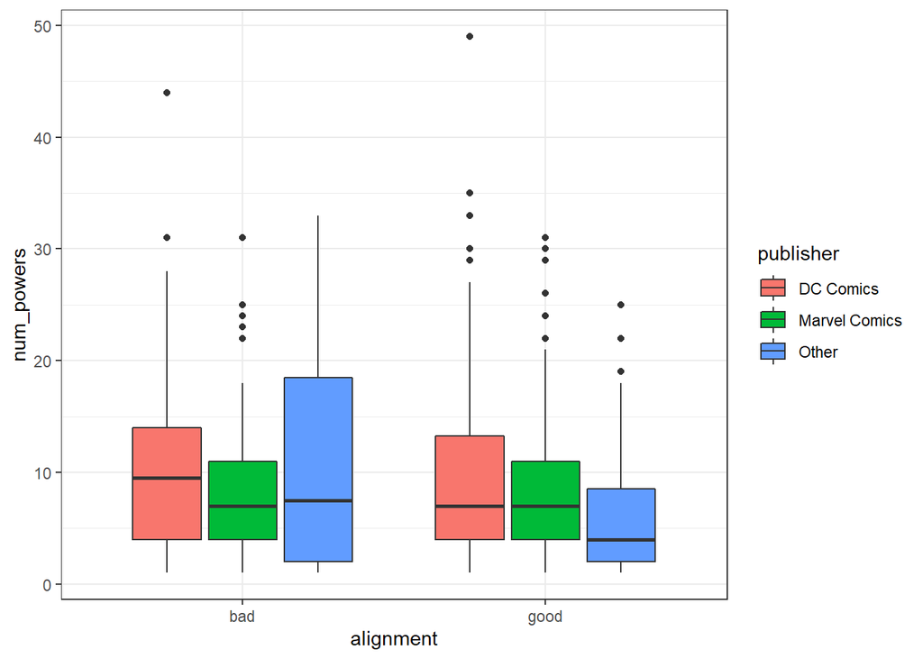

```r
super_hero_powers_transformed_df %>%
  inner_join(heroes_information_deduped_df[c('name', 'publisher', 'gender', 'alignment')], by = c("hero_names" = "name")) %>%
  mutate(num_powers = select(., agility:omniscient) %>% rowSums(na.rm=TRUE)) %>%
  select(hero_names, publisher, gender, alignment, num_powers) %>%
  filter(alignment %in% c('good', 'bad')) %>%
  mutate(publisher = fct_lump(publisher, n = 2)) %>%
  ggplot(aes(x=alignment, num_powers, fill = publisher)) +
  geom_boxplot()
```

Median value of the number of superpowers is almost the same for good superheroes from DC and Marvel Comics.